# Simple HTML

## A simple document

This is a simple html document, which is the document type that is the easiest to handle ($\LaTeX$ and Word is more difficult). However, I will also include example files for other document types.

## Formatting

It makes sense to start a new line for each sentence. This way, it is easier to see changes in version control (e.g. GitHub). In version control, changes are usually shown per line, and if a single line consists of 60 sentences, that becomes messy. You will notice that a line break is not the same as a return in a Word document.

To start a new paragraph, you need to leave a blank line.

### More formatting

The more # you add before a headline, the “lower,” the headline is. # indicated the title, ## is a second level headline etc. You get **bold text** (`**bold text**`) with two asterisks, and *italics* (`*italics*`) with one asterisk. You can get code in backticks: `This is code.` (`This is code.`) Backslashes can be used to escape characters that shouldn’t be a command, e.g. when you want to print an asterisk * instead of having italics.

You can include images like this (paths are always relative to the R Markdown file location):

[figure not shown]

```r
knitr::include_graphics("./pics/stackoverflow_meme.jpg")
```

## R code

You can use `R` code in code chunks like this:

```r
summary(cars)
```

```
##      speed           dist
##  Min.   : 4.0   Min.   :  2.00
##  1st Qu.:12.0   1st Qu.: 26.00
##  Median :15.0   Median : 36.00
##  Mean   :15.4   Mean   : 42.98
##  3rd Qu.:19.0   3rd Qu.: 56.00
##  Max.   :25.0   Max.   :120.00
```

Using the package `kableExtra`, you can get nice html tables:

```r
summary(iris) %>%
  kable() %>%
  kable_styling("striped")
```

|  | Sepal.Length | Sepal.Width | Petal.Length | Petal.Width | Species |
| --- | --- | --- | --- | --- | --- |
|  | Min. :4.300 | Min. :2.000 | Min. :1.000 | Min. :0.100 | setosa :50 |
|  | 1st Qu.:5.100 | 1st Qu.:2.800 | 1st Qu.:1.600 | 1st Qu.:0.300 | versicolor:50 |
|  | Median :5.800 | Median :3.000 | Median :4.350 | Median :1.300 | virginica :50 |
|  | Mean :5.843 | Mean :3.057 | Mean :3.758 | Mean :1.199 | NA |
|  | 3rd Qu.:6.400 | 3rd Qu.:3.300 | 3rd Qu.:5.100 | 3rd Qu.:1.800 | NA |
|  | Max. :7.900 | Max. :4.400 | Max. :6.900 | Max. :2.500 | NA |

You can also include plots. Here, the code is not shown because I used the chunk option `echo = FALSE`.

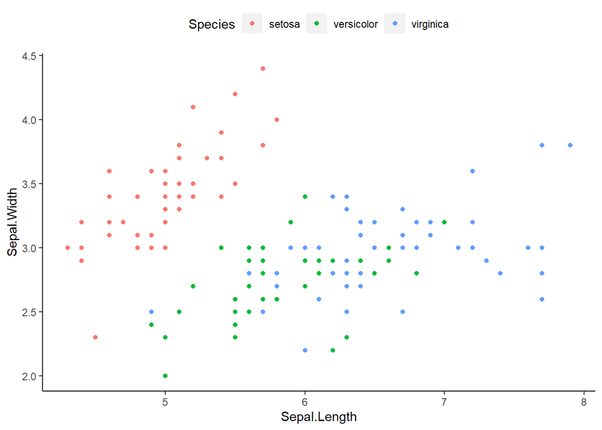

## Citations

At the top of the document, I defined a bibliography containing information about papers I want to cite in the BibTex format. You can download BibTex files for most papers on the website of the paper or generate one with your reference manager.

I can cite authors in the middle of the sentence like this: For example, Feld and Born (2017) write that … Or I can cite the paper in brackets at the end of a sentence (Feld and Born 2017). A reference list will automatically be generated. Note that you should add a references heading at the end of your document, otherwise, the reference list will be rendered directly after your text.

## References

Feld, Gordon B, and Jan Born. 2017. “Sculpting Memory During Sleep: Concurrent Consolidation and Forgetting.” *Current Opinion in Neurobiology* 44: 20–27. https://doi.org/https://doi.org/10.1016/j.conb.2017.02.012.